# MPDW Pertemuan 2

Nazuwa Aulia

2023-09-09

# Packages

```r
library(dplyr)
library(TTR)
library(forecast)
library(lmtest)
library(orcutt)
library(HoRM)
library(readr)
library(rio)
```

# Input Data

```r
data <-import("https://raw.githubusercontent.com/nazuwaaulia/MPDW/main/Pertemuan%202/New%20Delhi%20AQI%20dataset.csv")
View(data)
```

# Regresi Data

Alasan hanya diambil 3 peubah yaitu CO, o3 dan so2 adalah karena ketiga peubah ini memiliki nilai r square yang paling tinggi diantara peubah lain yang sudah dicoba sebelumnya

## Model Regresi

```r
model = lm(AQI~CO+o3+so2, data=data)
summary(model)
```

```
##
## Call:
## lm(formula = AQI ~ CO + o3 + so2, data = data)
##
## Residuals:
##     Min      1Q  Median      3Q     Max
## -0.6297 -0.3961 -0.0265  0.1540  4.3012
##
## Coefficients:
##              Estimate Std. Error t value Pr(>|t|)
## (Intercept) -2.130858   7.389425  -0.288    0.774
## CO          -0.002784   0.036556  -0.076    0.940
## o3           0.485279   0.024961  19.442   <2e-16 ***
## so2          3.894798   3.338980   1.166    0.248
## ---
## Signif. codes:  0 '***' 0.001 '**' 0.01 '*' 0.05 '.' 0.1 ' ' 1
##
## Residual standard error: 0.7034 on 68 degrees of freedom
## Multiple R-squared:  0.9492, Adjusted R-squared:  0.947
## F-statistic: 423.6 on 3 and 68 DF,  p-value: < 2.2e-16
```

## Pendeteksian multikolinieritas

```r
library(car)
vif(model)
```

```
##       CO       o3      so2
## 3.909863 3.697950 3.191173
```

Karena nilai VIF < 10 maka tidak terindikasi adanya multikolinieritas

## Sisaan dan fitted value

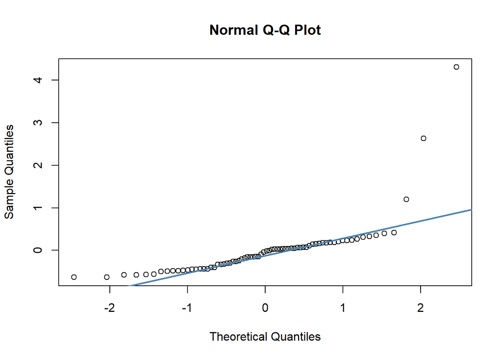

```r
sisaan <- residuals(model)
fitValue <- fitted(model)

#Diagnostik dengan eksploratif

#Uji Normalitas
qqnorm(sisaan)
qqline(sisaan, col = "steelblue", lwd = 2)
```

## Uji Nilai harapan sisaan = 0

```r
t.test(resid(model), mu = 0,)
```

```
##
##  One Sample t-test
##
## data:  resid(model)
## t = 1.8389e-15, df = 71, p-value = 1
## alternative hypothesis: true mean is not equal to 0
## 95 percent confidence interval:
##  -0.1617684  0.1617684
## sample estimates:
##    mean of x
## 1.491862e-16
```

Berdasarkan t-test didapatkan nilai *p-value* > $\alpha$ (5%) yaitu tak tolak H0 artinya cukup bukti untuk menyatakan bahwa nilai harapan sisaan sama dengan 0 pada taraf nyata 5%

## Uji Breusch-Pagan (Ragam sisaan homogen)

```r
lmtest::bptest(model)
```

```
##
##  studentized Breusch-Pagan test
##
## data:  model
## BP = 1.76, df = 3, p-value = 0.6237
```

Berdasarkan uji formal Breusch-Pagan didapatkan nilai *p-value* > $\alpha$ (5%) yaitu tak tolak H0 artinya cukup bukti untuk menyatakan bahwa ragam sisaan homogen pada taraf nyata 5%

## Uji Durbin Watson (kesalingbebasan sisaan)

```r
library(lmtest)
dwtest(model)
```

```
##
##  Durbin-Watson test
##
## data:  model
## DW = 0.55676, p-value = 1.13e-14
## alternative hypothesis: true autocorrelation is greater than 0
```

Berdasarkan uji formal Durbin-Watson didapatkan nilai *p-value* < $\alpha$ (5%) yaitu tolak H0 artinya tolak H0, dapat disimpulkan bahwa cukup bukti mengatakan adanya autokorelasi pada taraf nyata 5%. Oleh karena itu, diperlukan penanganan lebih lanjut terhadap autokorelasi. Penanganan yang akan dilakukan menggunakan dua metode, yaitu Cochrane-Orcutt dan Hildret-Lu.

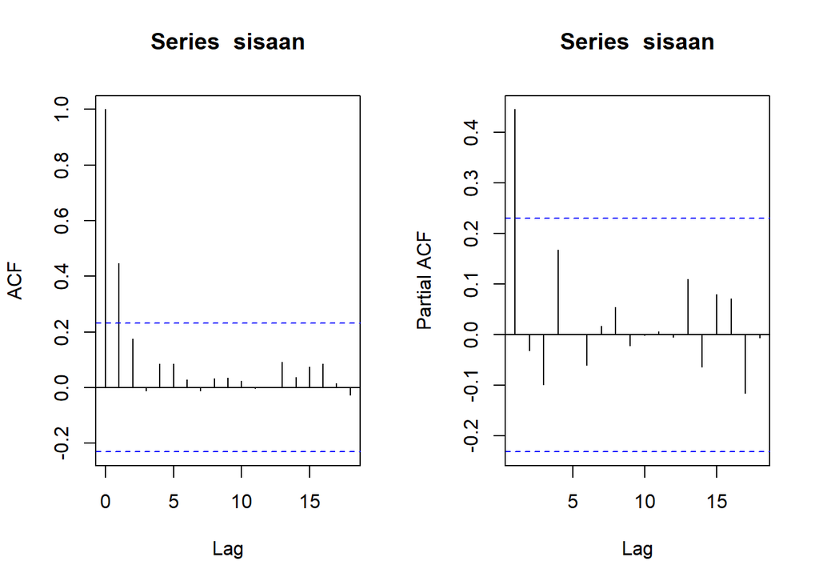

```r
#ACF dan PACF identifikasi autokorelasi
sisaan = model$residuals
par(mfrow = c(1,2))
acf(sisaan)
pacf(sisaan)
```

Noted : liat dari setelah 0 Berdasarkan plot ACF dan PACF, terlihat bahwa ada terdapat data yang berada diluar rentang batas autokorelasi.

# Penanganan Autokorelasi

## Metode Cochrane-Orcutt

```r
#Penanganan Autokorelasi Cochrane-Orcutt
modelCO<-cochrane.orcutt(model)
modelCO
```

```
## Cochrane-orcutt estimation for first order autocorrelation
##
## Call:
## lm(formula = AQI ~ CO + o3 + so2, data = data)
##
##  number of interaction: 9
##  rho 0.46121
##
## Durbin-Watson statistic
## (original):    0.55676 , p-value: 1.13e-14
## (transformed): 2.71731 , p-value: 9.976e-01
##
##  coefficients:
## (Intercept)          CO          o3         so2
##    4.989103   -0.031450    0.483940   -0.027116
```

### Rho optimum

```r
rho<- modelCO$rho
rho
```

```
## [1] 0.4612096
```

Untuk nilai $ρ ̂$ optimum yang digunakan adalah $0.4612096$

Selanjutnya akan dilakukan transformasi secara manual.

### Transformasi Manual

```r
AQI.trans <- data$AQI[-1]-data$AQI[-72]*rho
CO.trans <- data$CO[-1]-data$CO[-72]*rho
o3.trans <- data$o3[-1]-data$o3[-72]*rho
so2.trans <- data$so2[-1]-data$so2[-72]*rho
```

### Membentuk model dengan peubah yang sudah ditransformasi

```r
modelCOmanual<- lm(AQI.trans~CO.trans+o3.trans+so2.trans)
summary(modelCOmanual)
```

```
##
## Call:
## lm(formula = AQI.trans ~ CO.trans + o3.trans + so2.trans)
##
## Residuals:
##      Min       1Q   Median       3Q      Max
## -0.93684 -0.23232  0.04205  0.18381  0.79208
##
## Coefficients:
##             Estimate Std. Error t value Pr(>|t|)
## (Intercept)  2.68808    3.13685   0.857    0.395
## CO.trans    -0.03145    0.02819  -1.115    0.269
## o3.trans     0.48394    0.01940  24.943   <2e-16 ***
## so2.trans   -0.02712    2.69876  -0.010    0.992
## ---
## Signif. codes:  0 '***' 0.001 '**' 0.01 '*' 0.05 '.' 0.1 ' ' 1
##
## Residual standard error: 0.3435 on 67 degrees of freedom
## Multiple R-squared:  0.9635, Adjusted R-squared:  0.9619
## F-statistic: 589.6 on 3 and 67 DF,  p-value: < 2.2e-16
```

Hasil model transformasi bukan merupakan model sesungguhnya. Koefisien regresi masih perlu dicari

### Mencari Penduga Koefisien Regresi setelah Transformasi ke Persamaan Awal

```r
b0bintang <- modelCOmanual$coefficients[-c(2,3,4)]
b0 <- b0bintang/(1-rho)
b1 <- modelCOmanual$coefficients[-c(1,3,4)]
b2 <- modelCOmanual$coefficients[-c(1,2,4)]
b3 <- modelCOmanual$coefficients[-c(1,2,3)]
b0
```

```
## (Intercept)
##    4.989103
```

```r
b1
```

```
##   CO.trans
## -0.0314504
```

```r
b2
```

```
##  o3.trans
## 0.4839403
```

```r
b3
```

```
##   so2.trans
## -0.02711614
```

Hasil perhitungan koefisien regresi secara manual menghasilkan hasil yang sama dengan model yang dihasilkan menggunakan *packages*.

## Penanganan Autokorelasi Hildreth lu

```r
hildreth.lu.func<- function(r, model){
  x1 <- model.matrix(model)[,2]
  x2 <- model.matrix(model)[,3]
  x3 <- model.matrix(model)[,4]

  y <- model.response(model.frame(model))
  n <- length(y)
  t <- 2:n
  y <- y[t]-r*y[t-1]
  x1 <- x1[t]-r*x1[t-1]
  x2 <- x2[t]-r*x2[t-1]
  x3 <- x3[t]-r*x3[t-1]


  return(lm(y~x1+x2+x3))
}
```

### Pencarian rho yang meminimumkan SSE

```r
r <- c(seq(0.1,0.9, by= 0.1))
tab <- data.frame("rho" = r, "SSE" = sapply(r, function(i){deviance(hildreth.lu.func(i, model))}))
round(tab, 4)
```

```
##   rho     SSE
## 1 0.1 12.0739
## 2 0.2 10.0700
## 3 0.3  8.7231
## 4 0.4  8.0226
## 5 0.5  7.9523
## 6 0.6  8.4915
## 7 0.7  9.6241
## 8 0.8 11.3621
## 9 0.9 13.7733
```

Pertama-tama akan dicari di mana kira-kira $ρ$ yang menghasilkan SSE minimum. Pada hasil di atas terlihat $ρ$ minimum ketika 0.5. Namun, hasil tersebut masih kurang teliti sehingga akan dicari kembali $ρ$ yang lebih optimum dengan ketelitian yang lebih.

### Rho optimal

```r
rOpt <- seq(0.5,0.6, by= 0.001)
tabOpt <- data.frame("rho" = rOpt, "SSE" = sapply(rOpt, function(i){deviance(hildreth.lu.func(i, model))}))
head(tabOpt[order(tabOpt$SSE),])
```

```
##     rho      SSE
## 1 0.500 7.952266
## 2 0.501 7.954678
## 3 0.502 7.957150
## 4 0.503 7.959683
## 5 0.504 7.962276
## 6 0.505 7.964931
```

### Grafik SSE optimum

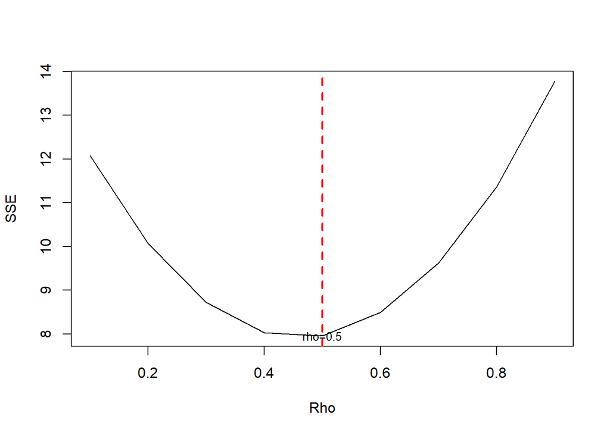

```r
par(mfrow = c(1,1))
plot(tab$SSE ~ tab$rho , type = "l", xlab = "Rho", ylab = "SSE")
abline(v = tabOpt[tabOpt$SSE==min(tabOpt$SSE),"rho"], lty = 2, col="red",lwd=2)
text(x=0.500, y=7.952266, labels = "rho=0.5", cex = 0.8)
```

Perhitungan yang dilakukan aplikasi `R` menunjukkan bahwa nilai $ρ$ optimum, yaitu saat SSE terkecil terdapat pada nilai $ρ=0.5$. Hal tersebut juga ditunjukkan pada plot. Selanjutnya, model dapat didapatkan dengan mengevaluasi nilai $ρ$ ke dalam fungsi `hildreth.lu.func`, serta dilanjutkan dengan pengujian autokorelasi dengan uji Durbin-Watson. Namun, setelah pengecekan tersebut tidak lupa koefisien regresi tersebut digunakan untuk transformasi balik. Persamaan hasil transformasi itulah yang menjadi persamaan sesungguhnya.

### Model terbaik

```r
modelHL <- hildreth.lu.func(0.5, model)
summary(modelHL)
```

```
##
## Call:
## lm(formula = y ~ x1 + x2 + x3)
##
## Residuals:
##      Min       1Q   Median       3Q      Max
## -0.97340 -0.23336  0.03454  0.19714  0.63550
##
## Coefficients:
##             Estimate Std. Error t value Pr(>|t|)
## (Intercept)  3.11362    3.05329   1.020    0.312
## x1          -0.03745    0.02947  -1.271    0.208
## x2           0.48569    0.02033  23.892   <2e-16 ***
## x3          -0.43020    2.84098  -0.151    0.880
## ---
## Signif. codes:  0 '***' 0.001 '**' 0.01 '*' 0.05 '.' 0.1 ' ' 1
##
## Residual standard error: 0.3445 on 67 degrees of freedom
## Multiple R-squared:  0.9589, Adjusted R-squared:  0.957
## F-statistic: 520.5 on 3 and 67 DF,  p-value: < 2.2e-16
```

### Transformasi Balik

```r
cat("y = ", coef(modelHL)[1]/(1-0.500), "+", coef(modelHL)[2],"x", sep = "")
```

```
## y = 6.227238+-0.0374496x
```

### Deteksi autokorelasi

```r
dwtest(modelHL)
```

```
##
##  Durbin-Watson test
##
## data:  modelHL
## DW = 2.7918, p-value = 0.9993
## alternative hypothesis: true autocorrelation is greater than 0
```

Terakhir, akan dibandingkan nilai SSE dari ketiga metode (metode awal, metode Cochrane-Orcutt, dan Hildreth-Lu).

## Perbandingan metode awal, metode Cochrane-Orcutt, dan Hildreth-Lu

```r
sseModelawal <- anova(model)$`Sum Sq`[-c(1,2,3)]
sseModelCO <- anova(modelCOmanual)$`Sum Sq`[-c(1,2,3)]
sseModelHL <- anova(modelHL)$`Sum Sq`[-c(1,2,3)]
mseModelawal <- sseModelawal/length(data$AQI)
mseModelCO <- sseModelCO/length(data$AQI)
mseModelHL <- sseModelHL/length(data$AQI)
akurasi <- matrix(c(sseModelawal,sseModelCO,sseModelHL,
                    mseModelawal,mseModelCO,mseModelHL),nrow=2,ncol=3,byrow = T)
colnames(akurasi) <- c("Model_Awal", "Model_Cochrane-Orcutt", "Model_Hildreth-Lu")
row.names(akurasi) <- c("SSE","MSE")
akurasi
```

```
##     Model_Awal Model_Cochrane-Orcutt Model_Hildreth-Lu
## SSE 33.6474846             7.9059848         7.9522665
## MSE  0.4673262             0.1098053         0.1104481
```

Berdasarkan hasil tersebut dapat diketahui bahwa hasil penanganan autokorelasi dengan metode Cochrane-Orcutt memiliki SSE sebesar $7.9059848$ dan Hildreth-Lu memiliki SSE sebesar $7.9522665$ keduanya lebih baik dibandingkan model awal ketika autokorelasi masih terjadi, yaitu sebesar $33.6474846$.

# Kesimpulan

Autokorelasi yang terdapat pada data terjadi akibat adanya korelasi di antara unsur penyusunnya.. Adanya autokorelasi menyebabkan model regresi kurang baik karena akan meingkatkan galatnya. Autokorelasi dapat dideteksi secara eksploratif melalui plot sisaan, ACF, dan PACF ataupun denga melakukan uji formal Durbin-Watson. Namun, autokorelasi tersebut dapat ditangani dengan metode Cochrane-Orcutt dan Hildreth-Lu. Kedua metode menghasilkan nilai SSE yang hampir mirip sehingga keduanya baik untuk digunakan dibandingkan model awal.